# visualization_assignment

```python
import matplotlib.pyplot as plt
import numpy as np
from mpl_toolkits.mplot3d import Axes3D
```

## Goles de Messi por cada año

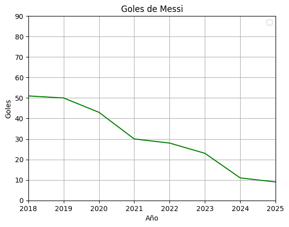

```python
plt.title("Goles de Messi")
plt.xlabel("Año")
plt.ylabel("Goles")
plt.grid(True)
plt.legend(['Goles'])
# Set axis limits
plt.xlim(2018, 2025)
plt.ylim(0, 90)
# Add text
plt.plot([2018,2019,2020,2021,2022,2023,2024,2025], [51,50,43,30,28,23,11,9], 'g-')
```

Este gráfico muestra los goles de Messi a lo largo de los años. Desde 2018 hasta 2025. Se eligió este tipo de gráfico ya que muestra como la cantidad de goles fue disminuyendo a lo largo de los años.

## Notas de las materias de Ingeniería Informática

```
<BarContainer object of 3 artists>
```

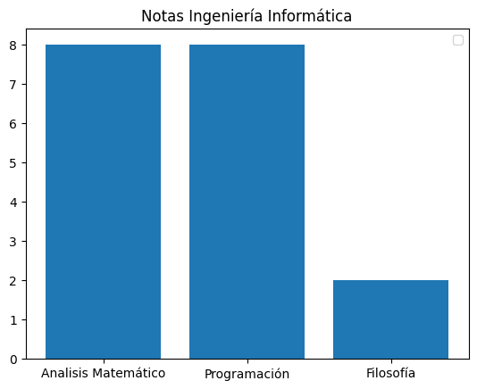

```python
plt.title("Notas Ingeniería Informática")
plt.legend(['Data Series'])
plt.bar(['Analisis Matemático','Programación','Filosofía'], [8,8,2])
```

Este gráfico muestra las notas que tuvo un alumno de Ingeniería Informática en las materias de Analisis matemático, Programación y Filosofía. Se usó este tipo de gráfico ya que se ve con claridad las distintas notas.

## Distrubución de notas

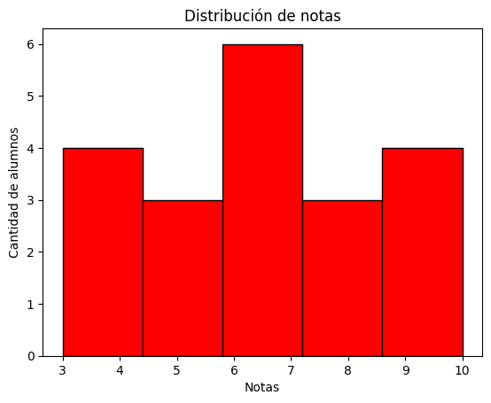

```python
notas = [4, 5, 7, 8, 6, 7, 10, 9, 8, 4, 6, 5, 6, 8, 7, 9, 10, 3, 4, 5]

plt.hist(notas, bins=5, edgecolor='black', color='red')

plt.xlabel('Notas')
plt.ylabel('Cantidad de alumnos')
plt.title('Distribución de notas')
```

En el gráfico se logra ver las distintas notas de varios estudiantes de Ingeniería Informática. Gracias a este gráfico se puede ver que nota es más común sacarse en promedio

## Relación de horas de estudio y nota obtenida

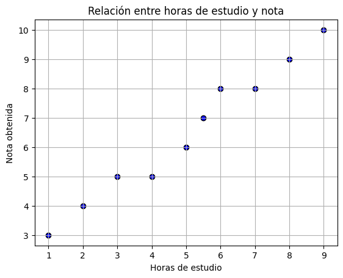

```python
horas_estudio = [1, 2, 3, 4, 5, 5.5, 6, 7, 8, 9]
notas =         [3, 4, 5, 5, 6, 7, 8, 8, 9, 10]

plt.scatter(horas_estudio, notas, color='blue', edgecolor='black')

plt.xlabel('Horas de estudio')
plt.ylabel('Nota obtenida')
plt.title('Relación entre horas de estudio y nota')
plt.grid(True)
```

En este gráfico se ve la relación entre las horas estudiadas y la nota obtenida. Se usó este tipo de gráfico ya que se puede ver en comparación a menos cantidad de horas estudiadas, la nota obtenida.

## Resultados del examen

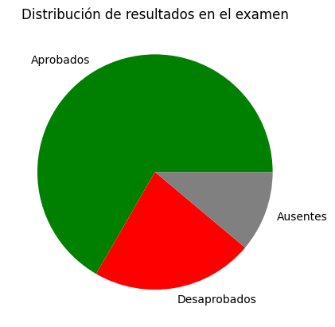

```python
categorias = ['Aprobados', 'Desaprobados', 'Ausentes']
cantidades = [18, 6, 3]

plt.pie(cantidades, labels=categorias, colors=['green', 'red', 'gray'])

# Título
plt.title('Distribución de resultados en el examen')
```

En este gráfico se observa en porcentaje la cantidad de aprobados, desaprobados y austentes de un examen de Ingeniería. Se usó el gráfico de torta ya que es el que mejor representa esta relación.